# Analyse des données avec R

08 janvier, 2022

## Importation de données

```r
fruit <- read.table(file="maturity_nirs.txt",header=TRUE,stringsAsFactors=TRUE)
fruit <- fruit %>% select(1:10,303:304) %>%mutate(Poids=1000*Poids,Diam=1000*Diam)
fruit <- fruit %>% mutate(Maturite=factor(Maturite))
fruit <- fruit %>% mutate(Maturite=recode_factor(Maturite,
  `1`="Faible",`2`="Moyenne",`3`="Forte",.ordered=TRUE))
colnames(fruit)
```

```
 [1] "Poids"      "Diam"       "L"          "a"          "b"
 [6] "Glucose"    "Fructose"   "Saccharose" "Citrate"    "Malate"
[11] "Variete"    "Maturite"
```

**Quelle est la variable la plus corrélée au taux de saccharose parmi le poids, le diamètre, L, a et b ?**

## Comparaison de modèles

## Exemple : prédiction du taux de sucre d’un fruit

**Modèle de régression linéaire multiple**

```r
mod <- lm(Saccharose~Poids+Diam+L+a+b,data=fruit)
coef(mod)
```

```
(Intercept)       Poids        Diam           L           a           b
    -8.7835      0.0260     -0.0105      0.1783      0.0951     -0.0158
```

**Qualité d’ajustement**

```r
summary(mod)$r.squared
```

```
[1] 0.464
```

## Un des effets est-il significatif ?

**Test de Fisher**

```r
mod0 = lm(Saccharose~1,data=fruit)
anova(mod0,mod) %>% kbl(caption="Analyse de la variance") %>%
  kable_paper(bootstrap_options = "striped", full_width = F)
```

Analyse de la variance

| Res.Df | RSS | Df | Sum of Sq | F | Pr(>F) |
| --- | --- | --- | --- | --- | --- |
| 434 | 1141 |  |  |  |  |
| 429 | 612 | 5 | 529 | 74.2 | 0 |

**Quelle conclusion en tirer ?**

## Confusion d’effets

**Quels sont les effets à retenir ?**

```r
car::Anova(mod) %>% kbl() %>%
  kable_paper(bootstrap_options = "striped", full_width = F)
```

|  | Sum Sq | Df | F value | Pr(>F) |
| --- | --- | --- | --- | --- |
| Poids | 7.025 | 1 | 4.926 | 0.027 |
| Diam | 0.092 | 1 | 0.065 | 0.799 |
| L | 274.771 | 1 | 192.703 | 0.000 |
| a | 223.813 | 1 | 156.965 | 0.000 |
| b | 3.950 | 1 | 2.770 | 0.097 |
| Residuals | 611.702 | 429 |  |  |

**Le diamètre apporte-t’il une information sur le taux de sucre ?**

## Sélection des effets

## Choix du meilleur modele

**Quel choix de variables explicatives ?**

```r
bestmod <- regsubsets(Saccharose~Poids+Diam+L+a+b,data=fruit)
tidy(bestmod) %>% dplyr::select(1:7) %>%
  kbl(caption="Recherche exhaustive du meilleur modèle") %>%
  kable_paper(bootstrap_options = "striped", full_width = F)
```

Recherche exhaustive du meilleur modèle

| (Intercept) | Poids | Diam | L | a | b | r.squared |
| --- | --- | --- | --- | --- | --- | --- |
| TRUE | FALSE | TRUE | FALSE | FALSE | FALSE | 0.191 |
| TRUE | FALSE | FALSE | TRUE | TRUE | FALSE | 0.433 |
| TRUE | TRUE | FALSE | TRUE | TRUE | FALSE | 0.460 |
| TRUE | TRUE | FALSE | TRUE | TRUE | TRUE | 0.464 |
| TRUE | TRUE | TRUE | TRUE | TRUE | TRUE | 0.464 |

## Est-ce vraiment le meilleur choix ?

**Performance de prédiction : validation croisée**

```r
mod <- glm(Saccharose~Poids+Diam+L+a+b,data=fruit)
msep <- cv.glm(data=fruit,glmfit=mod,K=10)$delta
sqrt(msep)
```

```
[1] 1.2 1.2
```

**Selon vous, quel choix de variables explicatives pour une bonne prédiction du taux de sucre ?**

## Qualité d’ajustement

**BIC (Bayesian Information Criterion) et AIC (Akaike IC)** : qualité d’ajustement d’un modèle tenant compte de sa complexité (nombre de paramètres)

```r
tidy(bestmod) %>% dplyr::select(c(1:6,9)) %>%
  kbl(caption="Recherche exhaustive du meilleur modèle") %>%
  kable_paper(bootstrap_options = "striped", full_width = F)
```

Recherche exhaustive du meilleur modèle

| (Intercept) | Poids | Diam | L | a | b | BIC |
| --- | --- | --- | --- | --- | --- | --- |
| TRUE | FALSE | TRUE | FALSE | FALSE | FALSE | -79.9 |
| TRUE | FALSE | FALSE | TRUE | TRUE | FALSE | -228.5 |
| TRUE | TRUE | FALSE | TRUE | TRUE | FALSE | -244.0 |
| TRUE | TRUE | FALSE | TRUE | TRUE | TRUE | -240.7 |
| TRUE | TRUE | TRUE | TRUE | TRUE | TRUE | -234.7 |

## Sélection pas à pas

**Comment prédire au mieux la maturité ?**

```r
mod <- multinom(Maturite~Poids+Diam+L+a+b,data=fruit,trace=FALSE)
select <- stepwise(mod,direction="forward/backward",criterion="BIC",trace=0)
```

```
Direction:  forward/backward
Criterion:  BIC
```

```r
coef(select)
```

```
        (Intercept)     a     L      b
Moyenne       -19.6 0.433 0.363 -0.120
Forte         -43.9 0.753 0.747 -0.219
```

**Le sens de la recherche affecte-t’il le résultat ?**

## Performance de prédiction du modele choisi

**Prédiction par la classe de probabilité maximale**

```r
predictions <- predict(select,newdata=fruit)
predictions <- ordered(predictions,levels=levels(fruit$Maturite))
table(fruit$Maturite,predictions) %>% kbl(caption="Matrice de confusion")
```

Matrice de confusion

|  | Faible | Moyenne | Forte |
| --- | --- | --- | --- |
| Faible | 134 | 17 | 0 |
| Moyenne | 23 | 96 | 37 |
| Forte | 1 | 40 | 87 |

```r
mean(fruit$Maturite==predictions)
```

```
[1] 0.729
```

## Performance de prédiction : validation croisée

**Segmentation aléatoire des données**

```r
segs <- fold(fruit,cat_col="Maturite",k=10)$.folds
cv_predictions <- fruit$Maturite
for (k in 1:10) {
  mod_train <- multinom(formula(select),data=fruit[segs!=k,],trace=FALSE)
  cv_predictions[segs==k] <- predict(mod_train,newdata=fruit[segs==k,],type="class")
}
```

**Taux d’affectations correctes : accuracy (10-fold CV)**

```r
mean(fruit$Maturite==cv_predictions)
```

```
[1] 0.736
```

## Caractérisation de groupes

## Quelle est la variable explicative la plus discriminante ?

**Evaluation du pouvoir discriminant : statistique F**

```r
vecF <- rep(0,times=5)
names(vecF) <- colnames(fruit)[1:5]
for (k in 1:5) {
  mod <- lm(x~Maturite,data=data.frame(x=fruit[,k],Maturite=fruit[,7]))
  vecF[k] <- summary(mod)$fstatistic[1]
}
t(vecF) %>% kbl() %>% kable_paper(bootstrap_options = "striped", full_width = F)
```

| Poids | Diam | L | a | b |
| --- | --- | --- | --- | --- |
| 2.58 | 0.204 | 0.769 | 28.5 | 55.7 |

## Scores linéaires les plus discriminants

**Quels scores linéaires discriminent le mieux les stades de maturité ?**

```r
Maturite.lda <- lda(Maturite~Poids+Diam+L+a+b,data=fruit)
coef(Maturite.lda) %>% t() %>% kbl() %>%
  kable_paper(bootstrap_options = "striped", full_width = F)
```

|  | Poids | Diam | L | a | b |
| --- | --- | --- | --- | --- | --- |
| LD1 | 0.010 | -0.063 | 0.224 | 0.204 | -0.058 |
| LD2 | -0.204 | 0.691 | -0.052 | 0.012 | -0.045 |

## Pouvoir discriminant du meilleur score

**Statistique de Fisher pour l’effet de la maturité**

```r
ld <- predict(Maturite.lda)$x
ld <- cbind.data.frame(ld,Maturite=fruit$Maturite)
mod <- lm(LD1~Maturite,data=ld)
summary(mod)$fstatistic
```

```
value numdf dendf
  324     2   432
```

## Caractérisation graphique des groupes

**Nuage des individus**

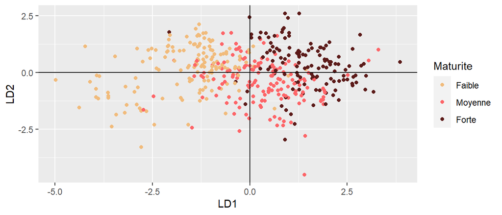

```r
ld %>% ggplot() + aes(x=LD1,y=LD2,col=Maturite) +
  scale_color_manual(values=wes_palette(n=3,name="GrandBudapest1")) +
  geom_point() + geom_hline(yintercept=0) + geom_vline(xintercept=0)
```

## Interprétation des scores discriminants

**Interprétation à partir des corrélations entre scores et variables explicatives**

```r
cor(ld[,1:2],fruit[,1:5]) %>%
  kbl(caption="Corrélations entre scores et variables explicatives") %>%
  kable_paper(bootstrap_options = "striped", full_width = F)
```

Corrélations entre scores et variables explicatives

|  | Poids | Diam | L | a | b |
| --- | --- | --- | --- | --- | --- |
| LD1 | 0.201 | 0.164 | 0.042 | 0.677 | 0.063 |
| LD2 | -0.206 | 0.219 | 0.138 | -0.105 | -0.215 |

## Prédiction à partir des scores discriminants

**Prédiction leave-one-out par la classe de probabilité maximale**

```r
Maturite.cvlda <- lda(Maturite~Poids+Diam+L+a+b,data=fruit,CV=TRUE)
predictions <- ordered(Maturite.cvlda$class)
table(fruit$Maturite,predictions) %>% kbl() %>%
  kable_paper(bootstrap_options = "striped", full_width = F)
```

|  | Faible | Moyenne | Forte |
| --- | --- | --- | --- |
| Faible | 128 | 22 | 1 |
| Moyenne | 26 | 104 | 26 |
| Forte | 1 | 28 | 99 |

```r
mean(fruit$Maturite==predictions)
```

```
[1] 0.761
```

## Données à haut débit

## Importation des données

```r
fruit2 <- read.table("maturity_nirs.txt",header=TRUE,stringsAsFactors = TRUE)
fruit2 <- fruit2 %>% select(-c(1:7,9:10))
fruit2 <- fruit2 %>% mutate(Maturite=factor(Maturite))
fruit2 <- fruit2 %>% mutate(Maturite=recode_factor(Maturite,
                              `1`="Faible",
                              `2`="Moyenne",
                              `3`="Forte",.ordered=TRUE))
fruit2[,2:293] <- t(scale(t(fruit2[,2:293])))
dim(fruit2)
```

```
[1] 435 295
```

**Un spectre = un grand nombre de variables explicatives**

## Données de spectrométrie proche infrarouge

**Longueurs d’onde dans le proche infrarouge**

```r
noms_cols <- colnames(fruit2)[2:293]
wl <- noms_cols %>% substring(first=3,last=10) %>% as.numeric()
range(wl)
```

```
[1]  989 1551
```

**Données en format long**

```r
nirs <- fruit2 %>% gather(Wl,Nirs,2:293)
nirs$Wl <- rep(wl,times=rep(435,292))
dim(nirs)
```

```
[1] 127020      5
```

## Visualisation de spectres proche infrarouge

**Spectres moyens par stade de maturité**

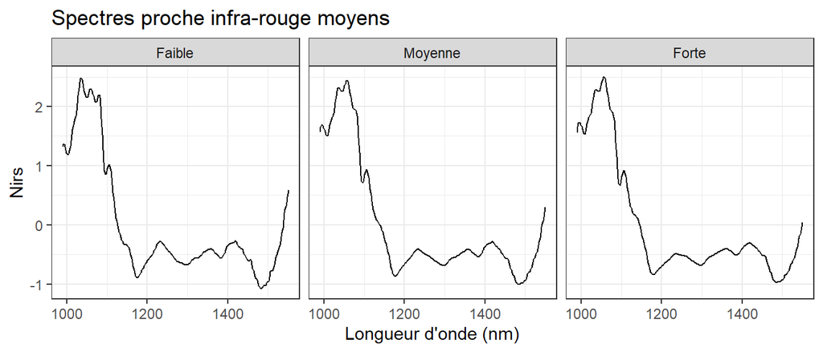

```r
nirs %>% ggplot(aes(x=Wl,y=Nirs)) + stat_summary(fun="mean",geom = "line") +
  facet_grid(. ~ Maturite) + theme_bw() + xlab("Longueur d'onde (nm)") + ylab("Nirs") +
  ggtitle("Spectres proche infra-rouge moyens")
```

## Modele de régression linéaire

**Prédiction du taux de sucre par le spectre**

```r
mod = lm(Saccharose~.,data=fruit2[,1:293])
summary(mod)$sigma^2
```

```
[1] 0.258
```

**Performance de prédiction - Validation croisée**

```r
mod = glm(Saccharose~.,data=fruit2[,1:293])
cv.glm(glmfit=mod,data=fruit2[,1:293],K=10)$delta[1]
```

```
[1] 1.3
```

**La variance de l’erreur de prédiction sur des données test est bien supérieure à celle observée sur les données d’apprentissage**

## Dimension + corrélation = estimation instable

**Estimation du modèle par la methode des moindres carrés**

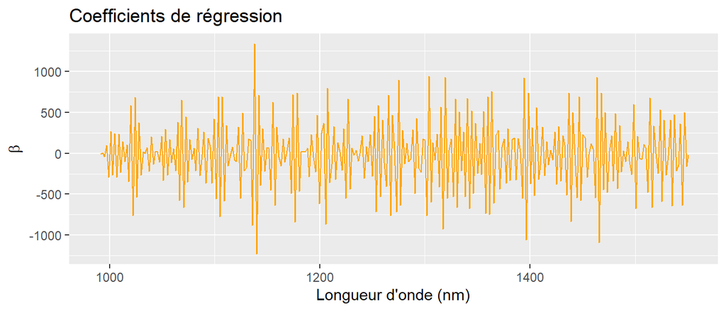

```r
df <- data.frame(wl = wl , beta = coef(mod)[-1])
df %>% ggplot(aes(x=wl,y=beta)) + geom_line(col="orange") + ylab(expression(beta)) +
  xlab("Longueur d'onde (nm)") + ggtitle("Coefficients de régression")
```

## Estimation régularisée

## Echange variance contre biais

**Un seul paramètre de régularisation** : \(\lambda \geq 0\)

```r
x <- fruit2 %>% dplyr::select(2:293) %>% as.matrix()
y <- fruit2$Saccharose
mod <- glmnet(x,y,lambda=c(0.01,0.001,0.0001),alpha=0,standardize = FALSE)
beta <- as.matrix(mod$beta)
beta %>% head(n=3) %>% kbl(caption="Estimation régularisée") %>%
  kable_paper(bootstrap_options = "striped", full_width = F)
```

Estimation régularisée

|  | s0 | s1 | s2 |
| --- | --- | --- | --- |
| X.1550.6826 | -0.337 | -1.460 | -6.458 |
| X.1548.7539 | -0.283 | -0.907 | -3.176 |
| X.1546.8252 | -0.206 | -0.551 | -0.897 |

## Régularisation de l’estimation

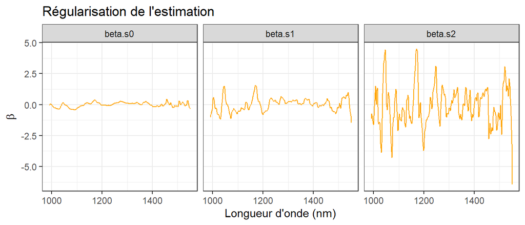

```r
df <- data.frame(wl = wl , beta = beta)
df <- df %>% gather(lambda,beta,2:4)
df %>% ggplot(aes(x=wl,y=beta)) + geom_line(col="orange") +
  facet_grid(. ~ lambda) + theme_bw() + xlab("Longueur d'onde (nm)") +
  ylab(expression(beta)) + ggtitle("Régularisation de l'estimation")
```

## Choix du paramètre de régularisation

**\(\lambda\) choisi pour optimiser la performance de prédiction**

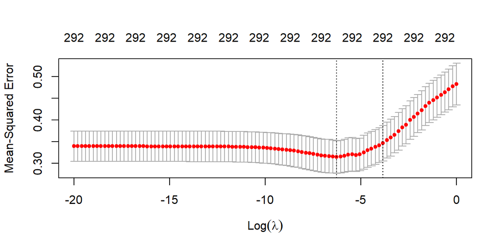

```r
log_lambda = seq(from=-20,to=0,length=100)
cvmod <- cv.glmnet(x,y,alpha=0,lambda=exp(log_lambda),type.measure="mse")
plot(cvmod)
```

## Compromis biais-variance

**Régularisation optimale**

```r
cvmod$lambda.min
```

```
[1] 0.00191
```

```r
min(cvmod$cvm)
```

```
[1] 0.315
```

**Avec cette même méthode d’estimation régularisée (“ridge regression”) :**

- **Construisez un outil de prédiction du stade de maturité à partir de la spectroscopie proche infra-rouge.**
- **Evaluez l’accuracy de cet outil.**

## Une alternative à la regression ridge : lasso

**Même principe de régularisation de l’estimation** :

```r
mod <- glmnet(x,y,lambda=c(0.01,0.0001,0.000001),alpha=1,standardize = FALSE)
beta <- as.matrix(mod$beta)
beta %>% head(n=3) %>% kbl(caption="Estimation régularisée (lasso)") %>%
  kable_paper(bootstrap_options = "striped", full_width = F)
```

Estimation régularisée (lasso)

|  | s0 | s1 | s2 |
| --- | --- | --- | --- |
| X.1550.6826 | -1.25 | -13.3 | -16.850 |
| X.1548.7539 | 0.00 | 0.0 | 0.256 |
| X.1546.8252 | 0.00 | 0.0 | -4.723 |

## Régularisation et sélection

**Estimation LASSO du modèle de régression**

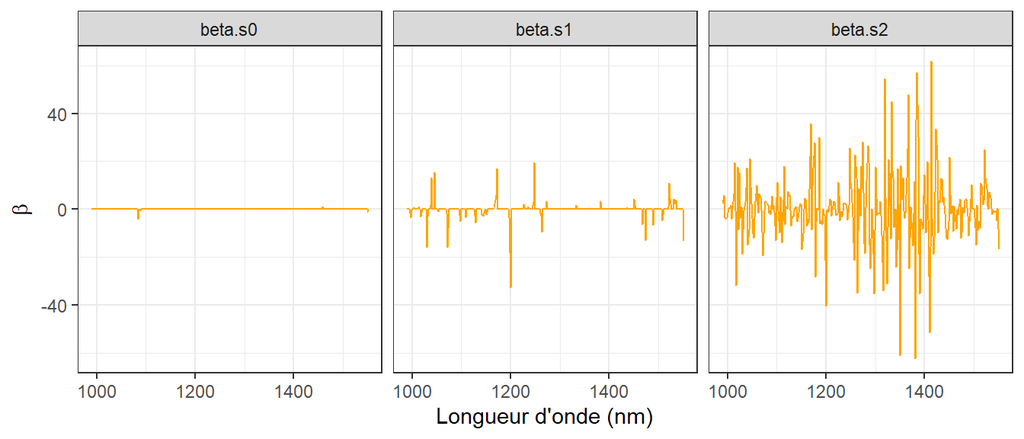

```r
df <- data.frame(wl = wl , beta = beta)
df <- df %>% gather(lambda,beta,2:4)
df %>% ggplot(aes(x=wl,y=beta)) + geom_line(col="orange") + theme_bw() +
  facet_grid(. ~ lambda) + ylab(expression(beta)) + xlab("Longueur d'onde (nm)")
```

## Choix du paramètre de régularisation

**Performance de prédiction - Validation croisée**

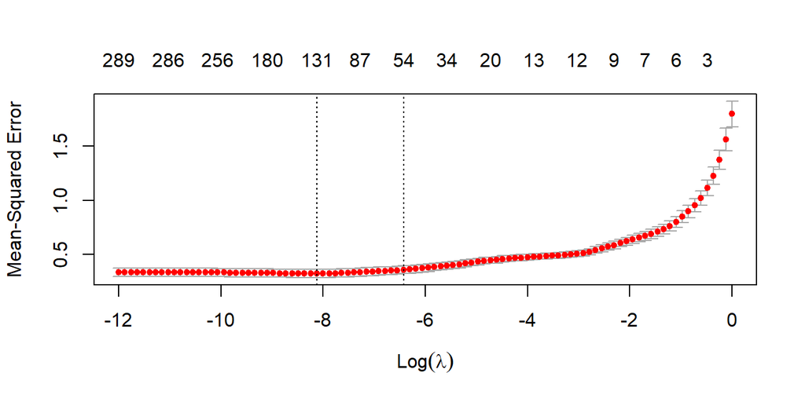

```r
log_lambda = seq(from=-12,to=0,length=100)
cvmod <- cv.glmnet(x,y,alpha=1,lambda=exp(log_lambda),type.measure="mse")
plot(cvmod)
```

## Compromis précision-parcimonie

**Régularisation optimale**

```r
cvmod$lambda.1se
```

```
[1] 0.00162
```

**Performance de prédiction**

```r
cvmod$cvm[cvmod$lambda==cvmod$lambda.1se]
```

```
[1] 0.357
```

## Parcimonie du modele de régression

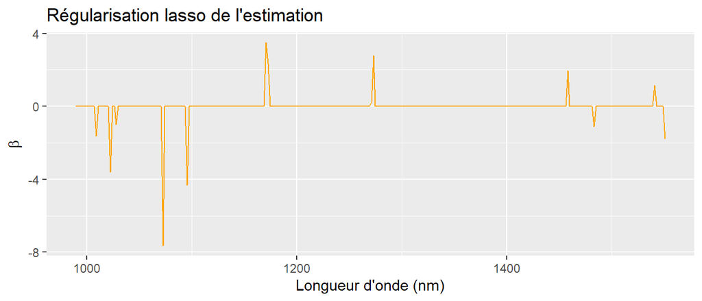

```r
mod <- glmnet(x,y,lambda=cvmod$lambda.1se,alpha=1,standardize = FALSE)
df <- data.frame(wl = wl , beta = mod$beta[,1])
df %>% ggplot(aes(x=wl,y=beta)) + geom_line(col="orange") +
  xlab("Longueur d'onde (nm)") + ylab(expression(beta)) +
  ggtitle("Régularisation lasso de l'estimation")
```

## Estimation à rang réduit

## Quelle est la meilleure variable explicative ?

**Evaluation de la performance de prédiction : validation croisée**

```r
x <- fruit2[,2:293]
y <- fruit2$Saccharose
vec_msep <- rep(0,times=ncol(x))
names(vec_msep) <- colnames(x)
for (k in 1:ncol(x)) {
  mod <- glm(y~x,data=data.frame(x=x[,k],y=y))
  vec_msep[k] <- cv.glm(data=data.frame(x=x[,k],y=y),glmfit=mod,
                        K=10)$delta[1]
}
min(vec_msep)
```

```
[1] 0.814
```

## Scores linéaires les plus prédictifs

**Quels scores linéaires prédisent le mieux le taux de sucre ?**

```r
saccharose.pls <- plsr(Saccharose~.,data=fruit2[,1:293])
scores.pls <- scores(saccharose.pls)[,]
k = 1
mod <- glm(y~x,data=data.frame(x=scores.pls[,k],y=y))
cv.glm(data=data.frame(x=scores.pls[,k],y=y),glmfit=mod,
                        K=10)$delta[1]
```

```
[1] 0.721
```

## Choix du nombre de scores à retenir

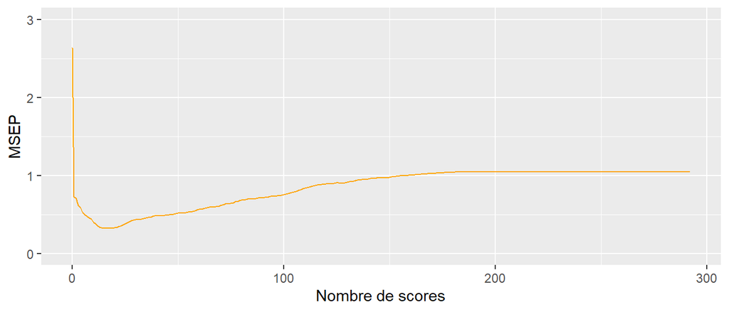

```r
saccharose.pls <- plsr(Saccharose~.,data=fruit2[,1:293],validation="CV",k=10)
msep <- MSEP(saccharose.pls)$val[1,1,]
data.frame(Nbcomp=0:292,MSEP=msep) %>% ggplot(aes(x=Nbcomp,y=MSEP)) + ylim(0,3) +
  geom_line(col="orange") + xlab("Nombre de scores")
```

## Pouvoir de prédiction des meilleurs scores

**Performance de prédiction par validation croisée**

```r
k_optimal <- (0:292)[which.min(msep)]
k_optimal
```

```
[1] 19
```

```r
min(msep)
```

```
[1] 0.325
```

## Interprétation des scores prédictifs

**Corrélation avec les variables explicatives**

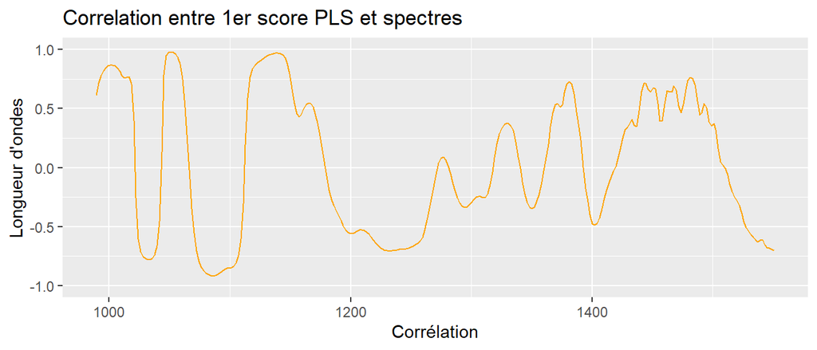

```r
cor1 <- cor(scores.pls[,1],x)[1,]
data.frame(Wl=wl,Cor=cor1) %>% ggplot(aes(x=Wl,y=Cor)) +
  geom_line(col="orange") + ylim(-1,1) + xlab("Corrélation") +
  ylab("Longueur d'ondes") + ggtitle("Correlation entre 1er score PLS et spectres")
```